# Data 621 - Homework 4

Group 2: William Aiken, Donald Butler, Michael Ippolito, Bharani Nittala, and Leticia Salazar

November 6, 2022

## Overview:

In this homework assignment, you will explore, analyze and model a data set containing approximately 8,000 records representing a customer at an auto insurance company. Each record has two response variables. The first response variable, TARGET_FLAG, is a 1 or a 0. A “1” means that the person was in a car crash. A zero means that the person was not in a car crash. The second response variable is TARGET_AMT. This value is zero if the person did not crash their car. But if they did crash their car, this number will be a value greater than zero.

## Objective:

Your objective is to build multiple linear regression and binary logistic regression models on the training data to predict the probability that a person will crash their car and also the amount of money it will cost if the person does crash their car. You can only use the variables given to you (or variables that you derive from the variables provided). Below is a short description of the variables of interest in the data set:

## Description:

Below is a short description of the variables of interest in the data set:

[output not shown]

### Load Libraries:

These are the libraries used to explore, prepare, analyze and build our models

```r
library(tidyverse)
library(caret)
library(pROC)
library(corrplot)
library(GGally)
library(psych)
library(car)
library(kableExtra)
library(gridExtra)
library(performance)
library(faraway)
library(jtools)
library(DataExplorer)
library(hrbrthemes)
library(MASS)
```

### Load Data set:

We have included the original data sets in our GitHub account and read from this location. Our training data set includes 8,161 records and 26 variables.

```
## Rows: 8,161
## Columns: 26
## $ INDEX       <int> 1, 2, 4, 5, 6, 7, 8, 11, 12, 13, 14, 15, 16, 17, 19, 20, 2…
## $ TARGET_FLAG <int> 0, 0, 0, 0, 0, 1, 0, 1, 1, 0, 1, 0, 0, 1, 1, 0, 0, 0, 0, 1…
## $ TARGET_AMT  <dbl> 0.000, 0.000, 0.000, 0.000, 0.000, 2946.000, 0.000, 4021.0…
## $ KIDSDRIV    <int> 0, 0, 0, 0, 0, 0, 0, 1, 0, 0, 0, 0, 0, 0, 0, 0, 0, 0, 0, 0…
## $ AGE         <int> 60, 43, 35, 51, 50, 34, 54, 37, 34, 50, 53, 43, 55, 53, 45…
## $ HOMEKIDS    <int> 0, 0, 1, 0, 0, 1, 0, 2, 0, 0, 0, 0, 0, 0, 0, 3, 0, 3, 2, 1…
## $ YOJ         <int> 11, 11, 10, 14, NA, 12, NA, NA, 10, 7, 14, 5, 11, 11, 0, 1…
## $ INCOME      <chr> "$67,349", "$91,449", "$16,039", "", "$114,986", "$125,301…
## $ PARENT1     <chr> "No", "No", "No", "No", "No", "Yes", "No", "No", "No", "No…
## $ HOME_VAL    <chr> "$0", "$257,252", "$124,191", "$306,251", "$243,925", "$0"…
## $ MSTATUS     <chr> "z_No", "z_No", "Yes", "Yes", "Yes", "z_No", "Yes", "Yes",…
## $ SEX         <chr> "M", "M", "z_F", "M", "z_F", "z_F", "z_F", "M", "z_F", "M"…
## $ EDUCATION   <chr> "PhD", "z_High School", "z_High School", "<High School", "…
## $ JOB         <chr> "Professional", "z_Blue Collar", "Clerical", "z_Blue Colla…
## $ TRAVTIME    <int> 14, 22, 5, 32, 36, 46, 33, 44, 34, 48, 15, 36, 25, 64, 48,…
## $ CAR_USE     <chr> "Private", "Commercial", "Private", "Private", "Private", …
## $ BLUEBOOK    <chr> "$14,230", "$14,940", "$4,010", "$15,440", "$18,000", "$17…
## $ TIF         <int> 11, 1, 4, 7, 1, 1, 1, 1, 1, 7, 1, 7, 7, 6, 1, 6, 6, 7, 4, …
## $ CAR_TYPE    <chr> "Minivan", "Minivan", "z_SUV", "Minivan", "z_SUV", "Sports…
## $ RED_CAR     <chr> "yes", "yes", "no", "yes", "no", "no", "no", "yes", "no", …
## $ OLDCLAIM    <chr> "$4,461", "$0", "$38,690", "$0", "$19,217", "$0", "$0", "$…
## $ CLM_FREQ    <int> 2, 0, 2, 0, 2, 0, 0, 1, 0, 0, 0, 0, 2, 0, 0, 0, 0, 0, 0, 2…
## $ REVOKED     <chr> "No", "No", "No", "No", "Yes", "No", "No", "Yes", "No", "N…
## $ MVR_PTS     <int> 3, 0, 3, 0, 3, 0, 0, 10, 0, 1, 0, 0, 3, 3, 3, 0, 0, 0, 0, …
## $ CAR_AGE     <int> 18, 1, 10, 6, 17, 7, 1, 7, 1, 17, 11, 1, 9, 10, 5, 13, 16,…
## $ URBANICITY  <chr> "Highly Urban/ Urban", "Highly Urban/ Urban", "Highly Urba…
```

## Data Exploration:

For insight on the data we use the `summary()` function on the train dataset:

```
##      INDEX        TARGET_FLAG       TARGET_AMT        KIDSDRIV
##  Min.   :    1   Min.   :0.0000   Min.   :     0   Min.   :0.0000
##  1st Qu.: 2559   1st Qu.:0.0000   1st Qu.:     0   1st Qu.:0.0000
##  Median : 5133   Median :0.0000   Median :     0   Median :0.0000
##  Mean   : 5152   Mean   :0.2638   Mean   :  1504   Mean   :0.1711
##  3rd Qu.: 7745   3rd Qu.:1.0000   3rd Qu.:  1036   3rd Qu.:0.0000
##  Max.   :10302   Max.   :1.0000   Max.   :107586   Max.   :4.0000
##
##       AGE           HOMEKIDS           YOJ          INCOME
##  Min.   :16.00   Min.   :0.0000   Min.   : 0.0   Length:8161
##  1st Qu.:39.00   1st Qu.:0.0000   1st Qu.: 9.0   Class :character
##  Median :45.00   Median :0.0000   Median :11.0   Mode  :character
##  Mean   :44.79   Mean   :0.7212   Mean   :10.5
##  3rd Qu.:51.00   3rd Qu.:1.0000   3rd Qu.:13.0
##  Max.   :81.00   Max.   :5.0000   Max.   :23.0
##  NA's   :6                        NA's   :454
##    PARENT1            HOME_VAL           MSTATUS              SEX
##  Length:8161        Length:8161        Length:8161        Length:8161
##  Class :character   Class :character   Class :character   Class :character
##  Mode  :character   Mode  :character   Mode  :character   Mode  :character
##
##
##
##
##   EDUCATION             JOB               TRAVTIME        CAR_USE
##  Length:8161        Length:8161        Min.   :  5.00   Length:8161
##  Class :character   Class :character   1st Qu.: 22.00   Class :character
##  Mode  :character   Mode  :character   Median : 33.00   Mode  :character
##                                        Mean   : 33.49
##                                        3rd Qu.: 44.00
##                                        Max.   :142.00
##
##    BLUEBOOK              TIF           CAR_TYPE           RED_CAR
##  Length:8161        Min.   : 1.000   Length:8161        Length:8161
##  Class :character   1st Qu.: 1.000   Class :character   Class :character
##  Mode  :character   Median : 4.000   Mode  :character   Mode  :character
##                     Mean   : 5.351
##                     3rd Qu.: 7.000
##                     Max.   :25.000
##
##    OLDCLAIM            CLM_FREQ        REVOKED             MVR_PTS
##  Length:8161        Min.   :0.0000   Length:8161        Min.   : 0.000
##  Class :character   1st Qu.:0.0000   Class :character   1st Qu.: 0.000
##  Mode  :character   Median :0.0000   Mode  :character   Median : 1.000
##                     Mean   :0.7986                      Mean   : 1.696
##                     3rd Qu.:2.0000                      3rd Qu.: 3.000
##                     Max.   :5.0000                      Max.   :13.000
##
##     CAR_AGE        URBANICITY
##  Min.   :-3.000   Length:8161
##  1st Qu.: 1.000   Class :character
##  Median : 8.000   Mode  :character
##  Mean   : 8.328
##  3rd Qu.:12.000
##  Max.   :28.000
##  NA's   :510
```

Let’s look at the statistical summary for the `dfeval` data as well:

```
##      INDEX       TARGET_FLAG    TARGET_AMT        KIDSDRIV           AGE
##  Min.   :    3   Mode:logical   Mode:logical   Min.   :0.0000   Min.   :17.00
##  1st Qu.: 2632   NA's:2141      NA's:2141      1st Qu.:0.0000   1st Qu.:39.00
##  Median : 5224                                 Median :0.0000   Median :45.00
##  Mean   : 5150                                 Mean   :0.1625   Mean   :45.02
##  3rd Qu.: 7669                                 3rd Qu.:0.0000   3rd Qu.:51.00
##  Max.   :10300                                 Max.   :3.0000   Max.   :73.00
##                                                                 NA's   :1
##     HOMEKIDS           YOJ           INCOME            PARENT1
##  Min.   :0.0000   Min.   : 0.00   Length:2141        Length:2141
##  1st Qu.:0.0000   1st Qu.: 9.00   Class :character   Class :character
##  Median :0.0000   Median :11.00   Mode  :character   Mode  :character
##  Mean   :0.7174   Mean   :10.38
##  3rd Qu.:1.0000   3rd Qu.:13.00
##  Max.   :5.0000   Max.   :19.00
##                   NA's   :94
##    HOME_VAL           MSTATUS              SEX             EDUCATION
##  Length:2141        Length:2141        Length:2141        Length:2141
##  Class :character   Class :character   Class :character   Class :character
##  Mode  :character   Mode  :character   Mode  :character   Mode  :character
##
##
##
##
##      JOB               TRAVTIME        CAR_USE            BLUEBOOK
##  Length:2141        Min.   :  5.00   Length:2141        Length:2141
##  Class :character   1st Qu.: 22.00   Class :character   Class :character
##  Mode  :character   Median : 33.00   Mode  :character   Mode  :character
##                     Mean   : 33.15
##                     3rd Qu.: 43.00
##                     Max.   :105.00
##
##       TIF           CAR_TYPE           RED_CAR            OLDCLAIM
##  Min.   : 1.000   Length:2141        Length:2141        Length:2141
##  1st Qu.: 1.000   Class :character   Class :character   Class :character
##  Median : 4.000   Mode  :character   Mode  :character   Mode  :character
##  Mean   : 5.245
##  3rd Qu.: 7.000
##  Max.   :25.000
##
##     CLM_FREQ       REVOKED             MVR_PTS          CAR_AGE
##  Min.   :0.000   Length:2141        Min.   : 0.000   Min.   : 0.000
##  1st Qu.:0.000   Class :character   1st Qu.: 0.000   1st Qu.: 1.000
##  Median :0.000   Mode  :character   Median : 1.000   Median : 8.000
##  Mean   :0.809                      Mean   : 1.766   Mean   : 8.183
##  3rd Qu.:2.000                      3rd Qu.: 3.000   3rd Qu.:12.000
##  Max.   :5.000                      Max.   :12.000   Max.   :26.000
##                                                      NA's   :129
##   URBANICITY
##  Length:2141
##  Class :character
##  Mode  :character
##
##
##
##
```

$~$

Distributions for training data set

```
## 4 columns ignored with more than 50 categories.
## INCOME: 6613 categories
## HOME_VAL: 5107 categories
## BLUEBOOK: 2789 categories
## OLDCLAIM: 2857 categories
```

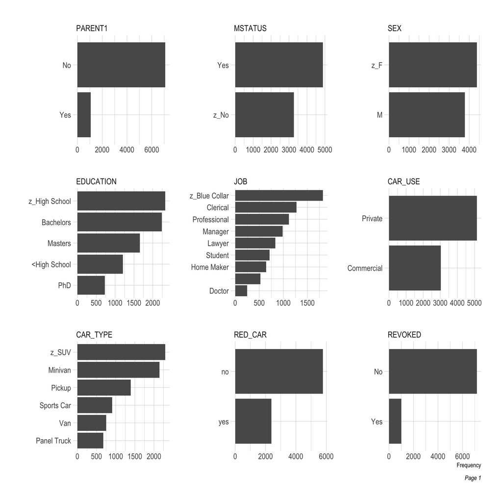

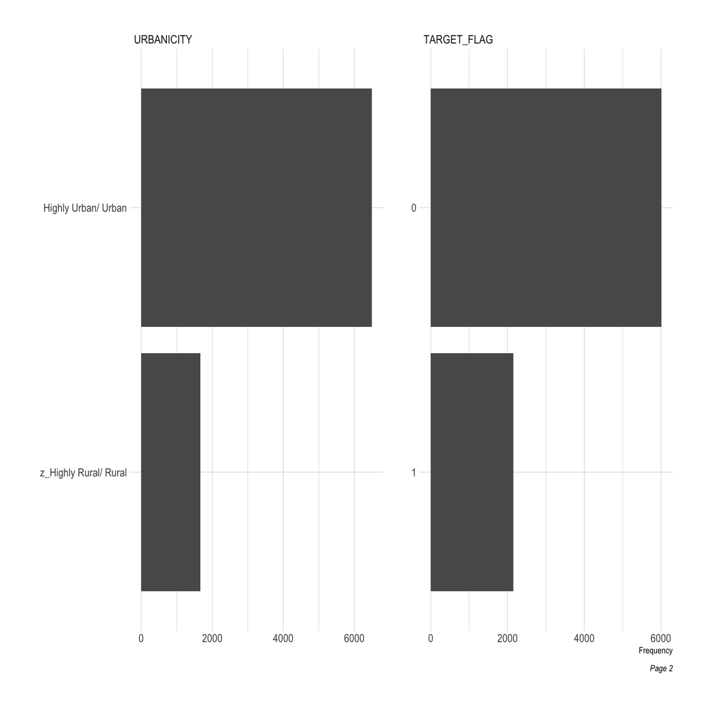

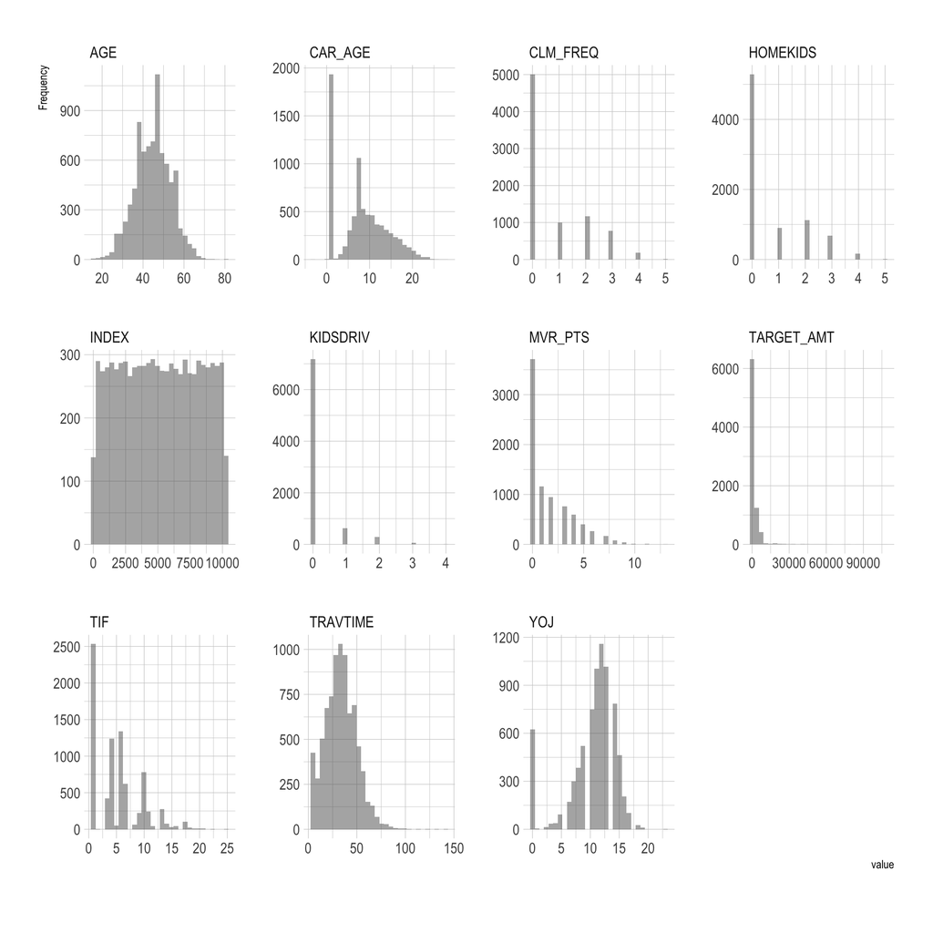

Distributions for evaluation data set

```
## 4 columns ignored with more than 50 categories.
## INCOME: 1804 categories
## HOME_VAL: 1398 categories
## BLUEBOOK: 1417 categories
## OLDCLAIM: 834 categories
```

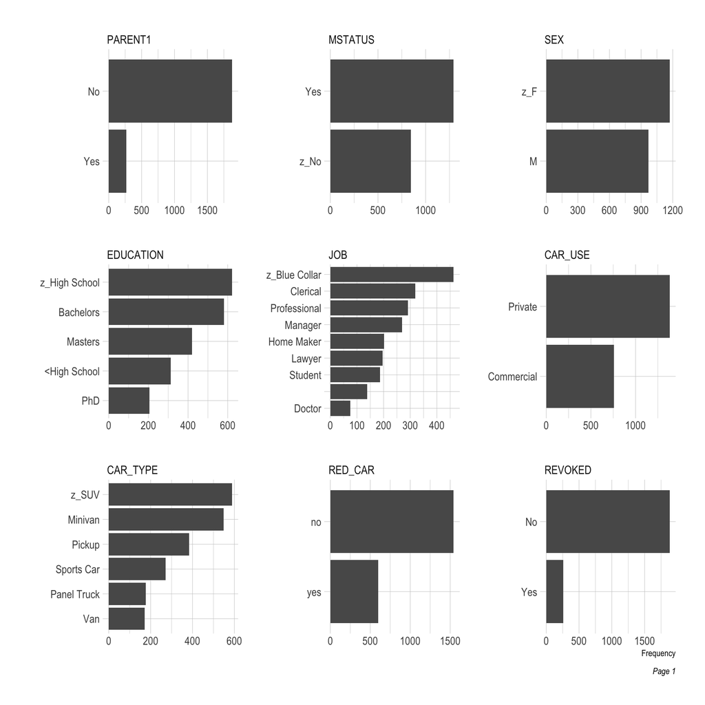

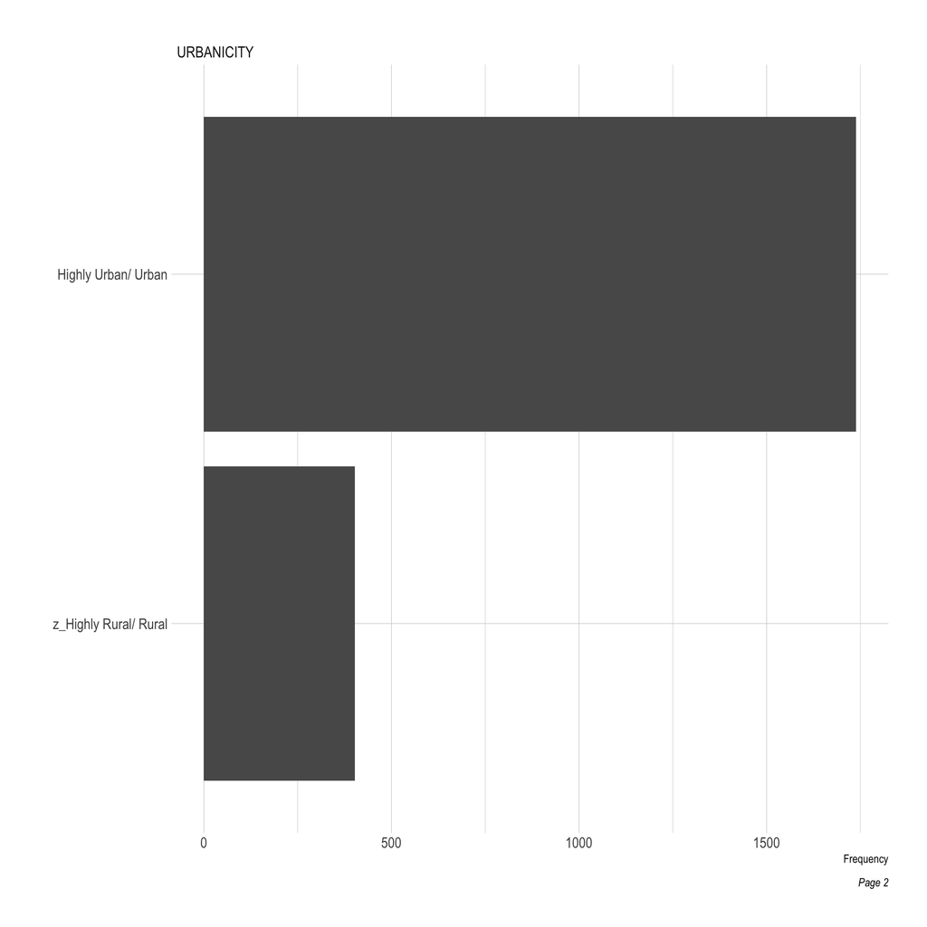

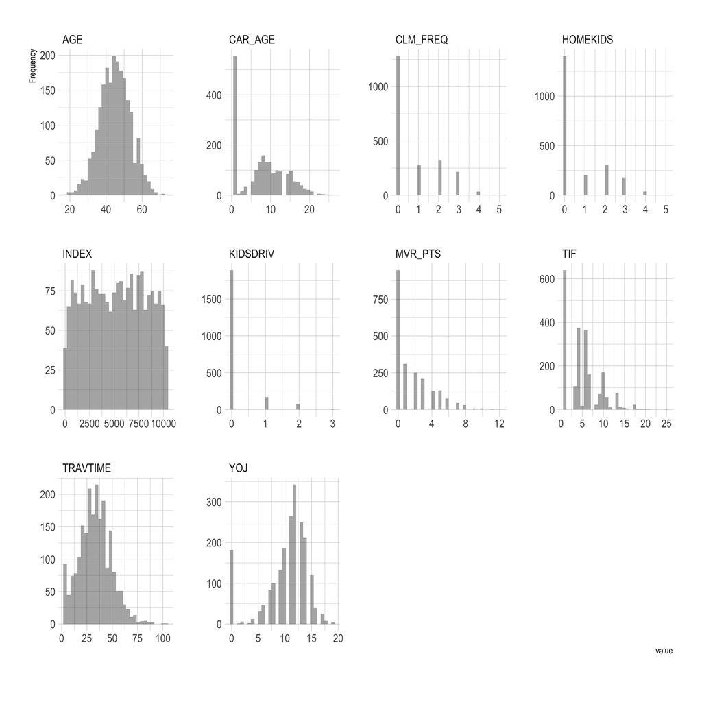

$~$

#### PARENT1

The *PARENT1* variable has two values, Yes and No, to indicate if the observation is a single parent. We will construct a dummy variable *SingleParent* = 1 if *PARENT1* = Yes.

```
##   PARENT1    n
## 1      No 7084
## 2     Yes 1077
```

```
##   PARENT1    n
## 1      No 1875
## 2     Yes  266
```

$~$

#### SEX

The *SEX* variable has two values, M and z_F. We will create a dummy variable *Male* = 1 if *SEX* = M.

```
##   SEX    n
## 1   M 3786
## 2 z_F 4375
```

```
##   SEX    n
## 1   M  971
## 2 z_F 1170
```

$~$

#### MSTATUS

The variable *MSTATUS* has two values, Yes and z_No, to indicate the marital status. We will create a dummy variable *Married* = 1 if MSTATUS = Yes.

```
##   MSTATUS    n
## 1     Yes 4894
## 2    z_No 3267
```

```
##   MSTATUS    n
## 1     Yes 1294
## 2    z_No  847
```

$~$

#### EDUCATION

The *EDUCATION* variable takes on 5 values ranging from less than high school through PHD. We will construct dummy variables: *HighSchool*, *Bachelors*, *Masters*, *PHD*, to indicate the highest level of education completed.

```
##       EDUCATION    n
## 1  <High School 1203
## 2     Bachelors 2242
## 3       Masters 1658
## 4           PhD  728
## 5 z_High School 2330
```

```
##       EDUCATION   n
## 1  <High School 312
## 2     Bachelors 581
## 3       Masters 420
## 4           PhD 206
## 5 z_High School 622
```

$~$

#### JOB

The *JOB* variable takes on 8 values. The *JOB* variable has 526 missing values, so we will construct dummy variables for all 8 values assuming the missing values are not one of the listed professions. The dummy variables we will create are: *Clerical*, *Doctor*, *HomeMaker*, *Lawyer*, *Manager*, *Professional*, *Student*, and *BlueCollar*.

```
##             JOB    n
## 1                526
## 2      Clerical 1271
## 3        Doctor  246
## 4    Home Maker  641
## 5        Lawyer  835
## 6       Manager  988
## 7  Professional 1117
## 8       Student  712
## 9 z_Blue Collar 1825
```

```
##             JOB   n
## 1               139
## 2      Clerical 319
## 3        Doctor  75
## 4    Home Maker 202
## 5        Lawyer 196
## 6       Manager 269
## 7  Professional 291
## 8       Student 187
## 9 z_Blue Collar 463
```

$~$

#### CAR_USE

The *CAR_USE* variable has two values, Commercial and Private. We will construct a dummy variable *Commercial* = 1 if Commercial.

```
##      CAR_USE    n
## 1 Commercial 3029
## 2    Private 5132
```

```
##      CAR_USE    n
## 1 Commercial  760
## 2    Private 1381
```

$~$

#### CAR_TYPE

The *CAR_TYPE* variable takes on 6 values. We will create dummy variables; *Minivan*, *PanelTruck*, *Pickup*, *SportsCar*, and *Van*.

```
##      CAR_TYPE    n
## 1     Minivan 2145
## 2 Panel Truck  676
## 3      Pickup 1389
## 4  Sports Car  907
## 5         Van  750
## 6       z_SUV 2294
```

```
##      CAR_TYPE   n
## 1     Minivan 549
## 2 Panel Truck 177
## 3      Pickup 383
## 4  Sports Car 272
## 5         Van 171
## 6       z_SUV 589
```

$~$

#### RED_CAR

The *RED_CAR* variable has two values, yes and no. We will create a dummy variable *RedCar* = 1 if *RED_CAR* = yes.

```
##   RED_CAR    n
## 1      no 5783
## 2     yes 2378
```

```
##   RED_CAR    n
## 1      no 1543
## 2     yes  598
```

$~$

#### REVOKED

The *REVOKED* variable has two values, Yes and No. We will create a dummy variable *DLRevoked* = 1 if *REVOKED* = Yes.

```
##   REVOKED    n
## 1      No 7161
## 2     Yes 1000
```

```
##   REVOKED    n
## 1      No 1880
## 2     Yes  261
```

$~$

#### URBANICITY

The *URBANICITY* variable has two values, Highly Urban/ Urban and z_Highly Rural/ Rural. We will create a dummy variable *Urban* = 1 if *URBANICITY* = Highly Urban/ Urban.

```
##              URBANICITY    n
## 1   Highly Urban/ Urban 6492
## 2 z_Highly Rural/ Rural 1669
```

```
##              URBANICITY    n
## 1   Highly Urban/ Urban 1738
## 2 z_Highly Rural/ Rural  403
```

## Data Preparation:

Performed to both the training and evaluation data sets but will only be displayed for the training data.

$~$

#### Data Cleaning Function

Checking for missing values for the training data set. This includes NAs that might be introduced as a result of conversion to numeric.

```
##       INDEX TARGET_FLAG  TARGET_AMT    KIDSDRIV         AGE    HOMEKIDS
##           0           0           0           0           6           0
##         YOJ      INCOME     PARENT1    HOME_VAL     MSTATUS         SEX
##         454           0           0           0           0           0
##   EDUCATION         JOB    TRAVTIME     CAR_USE    BLUEBOOK         TIF
##           0           0           0           0           0           0
##    CAR_TYPE     RED_CAR    OLDCLAIM    CLM_FREQ     REVOKED     MVR_PTS
##           0           0           0           0           0           0
##     CAR_AGE  URBANICITY
##         510           0
```

```
##   BLUEBOOK HOME_VAL INCOME OLDCLAIM
## 1        0      464    445        0
```

- The attributes `BLUEBOOK`, `HOME_VAL`, `INCOME`, and`OLDCLAIM` are dollar amounts stored as characters. Need to convert to int. It is noted that converting blank values to numeric introduces some NAs; therefore our cleaning function will handle these cases.
- Variables with NA: `AGE` (6), `YOJ` (454), `CAR_AGE` (510)
- Consider creating `AGE` groups Under25 and Over65 to account for young and older drivers.
- Consider creating `CAR_AGE` groups to identify new cars. One observation has a `CAR_AGE` = -3, which shouldn’t be possible.
- Consider creating `YOJ` (Year on Job) groups to identify job stability; Over5years etc.

```
##   INDEX TARGET_FLAG TARGET_AMT KIDSDRIV AGE HOMEKIDS YOJ INCOME HOME_VAL
## 1     1           0          0        0  60        0  11  67349        0
## 2     2           0          0        0  43        0  11  91449   257252
## 3     4           0          0        0  35        1  10  16039   124191
## 4     5           0          0        0  51        0  14  54028   306251
## 5     6           0          0        0  50        0  11 114986   243925
## 6     7           1       2946        0  34        1  12 125301        0
##   TRAVTIME BLUEBOOK TIF OLDCLAIM CLM_FREQ MVR_PTS CAR_AGE SingleParent Male
## 1       14    14230  11     4461        2       3      18            0    1
## 2       22    14940   1        0        0       0       1            0    1
## 3        5     4010   4    38690        2       3      10            0    0
## 4       32    15440   7        0        0       0       6            0    1
## 5       36    18000   1    19217        2       3      17            0    0
## 6       46    17430   1        0        0       0       7            1    0
##   Married HighSchool Bachelors Masters PHD Clerical Doctor HomeMaker Lawyer
```

[output cut: 20 more lines]

Checking for missing values for the evaluation data set, including NAs that might be introduced as a result of conversion to numeric. The TARGET_FLAG and TARGET_AMT are the response variables so should remain NA for now.

```
##       INDEX TARGET_FLAG  TARGET_AMT    KIDSDRIV         AGE    HOMEKIDS
##           0        2141        2141           0           1           0
##         YOJ      INCOME     PARENT1    HOME_VAL     MSTATUS         SEX
##          94           0           0           0           0           0
##   EDUCATION         JOB    TRAVTIME     CAR_USE    BLUEBOOK         TIF
##           0           0           0           0           0           0
##    CAR_TYPE     RED_CAR    OLDCLAIM    CLM_FREQ     REVOKED     MVR_PTS
##           0           0           0           0           0           0
##     CAR_AGE  URBANICITY
##         129           0
```

```
##   BLUEBOOK HOME_VAL INCOME OLDCLAIM
## 1        0      111    125        0
```

$~$

The correlation plot below is measuring the degree of linear relationship within the cleaned training data. The values in which this is measured falls between -1 and +1, with +1 being a strong positive correlation and -1 a strong negative correlation.

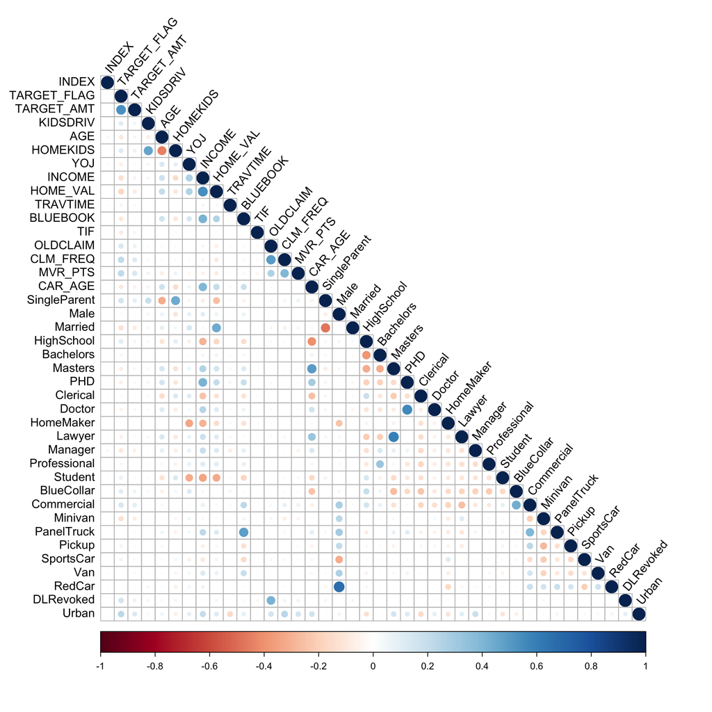

$~$

## Model Building:

We will be building six different models; three multiple linear regression (MLR) models and three binary logistic regression (BLR) models.

### **Model 1**

MLR: Base model where all variables are tested

```
##
## Call:
## lm(formula = TARGET_AMT ~ ., data = cleandf, na.action = na.omit)
##
## Residuals:
##    Min     1Q Median     3Q    Max
##  -6294   -470    -56    239 101122
##
## Coefficients:
##                Estimate Std. Error t value Pr(>|t|)
## (Intercept)  -6.066e+02  4.746e+02  -1.278 0.201221
## INDEX        -1.474e-03  1.480e-02  -0.100 0.920691
## TARGET_FLAG   5.705e+03  1.136e+02  50.240  < 2e-16 ***
## KIDSDRIV     -3.096e+01  9.910e+01  -0.312 0.754743
## AGE           5.941e+00  6.175e+00   0.962 0.336051
## HOMEKIDS      3.970e+01  5.710e+01   0.695 0.486936
## YOJ           8.275e+00  1.318e+01   0.628 0.530161
## INCOME       -2.265e-03  1.577e-03  -1.436 0.151171
## HOME_VAL      4.051e-04  5.164e-04   0.784 0.432786
## TRAVTIME      5.643e-01  2.825e+00   0.200 0.841655
## BLUEBOOK      2.933e-02  7.538e-03   3.891 0.000101 ***
## TIF          -2.946e+00  1.068e+01  -0.276 0.782577
## OLDCLAIM      3.055e-03  6.502e-03   0.470 0.638492
## CLM_FREQ     -4.333e+01  4.822e+01  -0.899 0.368906
## MVR_PTS       5.404e+01  2.277e+01   2.374 0.017641 *
## CAR_AGE      -2.526e+01  1.118e+01  -2.260 0.023843 *
## SingleParent  1.401e+02  1.767e+02   0.793 0.427820
## Male          2.871e+02  1.605e+02   1.788 0.073756 .
## Married      -1.711e+02  1.268e+02  -1.350 0.177187
## HighSchool   -1.227e+02  1.502e+02  -0.817 0.414191
## Bachelors     6.954e+01  1.791e+02   0.388 0.697744
## Masters       2.263e+02  2.621e+02   0.863 0.387952
## PHD           4.323e+02  3.110e+02   1.390 0.164631
## Clerical     -5.782e+00  2.985e+02  -0.019 0.984544
## Doctor       -2.783e+02  3.571e+02  -0.779 0.435838
## HomeMaker    -6.523e+01  3.186e+02  -0.205 0.837805
## Lawyer        7.743e+01  2.583e+02   0.300 0.764368
## Manager      -1.210e+02  2.521e+02  -0.480 0.631160
## Professional  1.762e+02  2.698e+02   0.653 0.513667
## Student      -1.263e+02  3.268e+02  -0.387 0.699045
## BlueCollar    5.726e+01  2.813e+02   0.204 0.838705
## Commercial    9.624e+01  1.443e+02   0.667 0.504755
## Minivan      -1.600e+02  1.571e+02  -1.019 0.308382
## PanelTruck   -2.123e+02  2.976e+02  -0.713 0.475594
## Pickup       -1.903e+02  1.740e+02  -1.094 0.274059
## SportsCar     4.487e+01  1.563e+02   0.287 0.774114
## Van          -6.419e+01  2.334e+02  -0.275 0.783290
## RedCar       -2.855e+01  1.302e+02  -0.219 0.826416
## DLRevoked    -3.273e+02  1.526e+02  -2.145 0.031984 *
## Urban        -3.380e+01  1.264e+02  -0.267 0.789103
## ---
## Signif. codes:  0 '***' 0.001 '**' 0.01 '*' 0.05 '.' 0.1 ' ' 1
##
## Residual standard error: 3970 on 8121 degrees of freedom
## Multiple R-squared:  0.2913, Adjusted R-squared:  0.2879
## F-statistic: 85.59 on 39 and 8121 DF,  p-value: < 2.2e-16
```

$~$

### **Model 2**

MLR: Backward Elimination

```
##
## Call:
## lm(formula = TARGET_AMT ~ KIDSDRIV + HOMEKIDS + INCOME + SingleParent +
##     HOME_VAL + Married + TRAVTIME + BLUEBOOK + TIF + CLM_FREQ +
##     MVR_PTS + CAR_AGE, data = cleandf, na.action = na.omit)
##
## Residuals:
##    Min     1Q Median     3Q    Max
##  -5441  -1601   -887    -81 104296
##
## Coefficients:
##                Estimate Std. Error t value Pr(>|t|)
## (Intercept)   1.377e+03  2.119e+02   6.499 8.54e-11 ***
## KIDSDRIV      2.899e+02  1.129e+02   2.568 0.010241 *
## HOMEKIDS      6.561e+01  6.012e+01   1.091 0.275139
## INCOME       -3.171e-03  1.559e-03  -2.034 0.042013 *
## SingleParent  5.607e+02  2.036e+02   2.754 0.005903 **
## HOME_VAL     -4.514e-04  5.841e-04  -0.773 0.439702
## Married      -5.567e+02  1.454e+02  -3.830 0.000129 ***
## TRAVTIME      7.282e+00  3.215e+00   2.265 0.023554 *
## BLUEBOOK      1.632e-02  6.692e-03   2.438 0.014770 *
## TIF          -4.564e+01  1.232e+01  -3.704 0.000214 ***
## CLM_FREQ      2.708e+02  4.814e+01   5.627 1.90e-08 ***
## MVR_PTS       2.165e+02  2.600e+01   8.327  < 2e-16 ***
## CAR_AGE      -3.422e+01  1.010e+01  -3.388 0.000709 ***
## ---
## Signif. codes:  0 '***' 0.001 '**' 0.01 '*' 0.05 '.' 0.1 ' ' 1
##
## Residual standard error: 4611 on 8148 degrees of freedom
## Multiple R-squared:  0.04059,    Adjusted R-squared:  0.03918
## F-statistic: 28.73 on 12 and 8148 DF,  p-value: < 2.2e-16
```

$~$

### **Model 3**

MLR: BoxCox Transformation

```
##
## Call:
## lm(formula = TARGET_AMT ~ ., data = model_bc_transformed)
##
## Residuals:
##    Min     1Q Median     3Q    Max
##  -6281   -473    -70    240 101112
##
## Coefficients:
##                Estimate Std. Error t value Pr(>|t|)
## (Intercept)  -1.049e+03  5.020e+02  -2.090   0.0366 *
## INDEX        -2.855e-02  1.799e-01  -0.159   0.8739
## TARGET_FLAG   5.712e+03  1.136e+02  50.265  < 2e-16 ***
## KIDSDRIV     -3.309e+01  9.907e+01  -0.334   0.7384
## AGE           5.658e+00  6.170e+00   0.917   0.3591
## HOMEKIDS      4.026e+01  5.708e+01   0.705   0.4806
## YOJ           7.698e+00  1.318e+01   0.584   0.5592
## INCOME       -2.182e-03  1.570e-03  -1.389   0.1648
## HOME_VAL      4.100e-04  5.163e-04   0.794   0.4271
## TRAVTIME      1.132e+00  7.904e+00   0.143   0.8861
## BLUEBOOK      3.914e+00  8.966e-01   4.366 1.28e-05 ***
## TIF          -1.001e+01  3.648e+01  -0.274   0.7837
## OLDCLAIM      2.973e-03  6.501e-03   0.457   0.6475
## CLM_FREQ     -4.300e+01  4.821e+01  -0.892   0.3725
## MVR_PTS       5.407e+01  2.276e+01   2.376   0.0175 *
## CAR_AGE      -2.530e+01  1.118e+01  -2.264   0.0236 *
## SingleParent  1.404e+02  1.766e+02   0.795   0.4268
## Male          2.973e+02  1.592e+02   1.867   0.0619 .
## Married      -1.694e+02  1.268e+02  -1.337   0.1813
## HighSchool   -1.280e+02  1.502e+02  -0.852   0.3942
## Bachelors     5.995e+01  1.791e+02   0.335   0.7378
## Masters       2.143e+02  2.621e+02   0.818   0.4136
## PHD           4.295e+02  3.110e+02   1.381   0.1673
## Clerical     -8.202e+00  2.984e+02  -0.027   0.9781
## Doctor       -2.881e+02  3.570e+02  -0.807   0.4197
## HomeMaker    -5.052e+01  3.186e+02  -0.159   0.8740
## Lawyer        7.012e+01  2.582e+02   0.272   0.7860
## Manager      -1.294e+02  2.521e+02  -0.513   0.6077
## Professional  1.685e+02  2.697e+02   0.625   0.5321
## Student      -1.074e+02  3.268e+02  -0.329   0.7425
## BlueCollar    4.794e+01  2.813e+02   0.170   0.8647
## Commercial    9.375e+01  1.442e+02   0.650   0.5157
## Minivan      -1.731e+02  1.558e+02  -1.111   0.2665
## PanelTruck   -2.116e+02  2.880e+02  -0.735   0.4624
## Pickup       -1.920e+02  1.730e+02  -1.110   0.2672
## SportsCar     6.424e+01  1.565e+02   0.411   0.6814
## Van          -9.857e+01  2.320e+02  -0.425   0.6709
## RedCar       -2.673e+01  1.302e+02  -0.205   0.8373
## DLRevoked    -3.258e+02  1.525e+02  -2.136   0.0327 *
## Urban        -3.716e+01  1.262e+02  -0.294   0.7684
## ---
## Signif. codes:  0 '***' 0.001 '**' 0.01 '*' 0.05 '.' 0.1 ' ' 1
##
## Residual standard error: 3969 on 8121 degrees of freedom
## Multiple R-squared:  0.2916, Adjusted R-squared:  0.2882
## F-statistic: 85.73 on 39 and 8121 DF,  p-value: < 2.2e-16
```

$~$

### **Model 4**

BLR: Base model where all variables are tested

```
##
## Call:
## glm(formula = TARGET_FLAG ~ ., family = binomial(link = "logit"),
##     data = cleandf)
##
## Deviance Residuals:
##       Min         1Q     Median         3Q        Max
## -0.002566   0.000000   0.000000   0.000000   0.003951
##
## Coefficients:
##                Estimate Std. Error z value Pr(>|z|)
## (Intercept)  -7.925e+01  4.747e+04  -0.002    0.999
## INDEX         1.275e-03  1.589e-01   0.008    0.994
## TARGET_AMT    3.404e-01  2.912e+00   0.117    0.907
## KIDSDRIV      1.201e+01  6.447e+02   0.019    0.985
## AGE          -3.028e-01  4.185e+01  -0.007    0.994
## HOMEKIDS     -3.823e+00  5.871e+02  -0.007    0.995
## YOJ          -1.135e+00  7.419e+01  -0.015    0.988
## INCOME        1.929e-05  1.422e-02   0.001    0.999
## HOME_VAL      1.736e-05  4.655e-03   0.004    0.997
## TRAVTIME      1.350e-03  1.907e+01   0.000    1.000
## BLUEBOOK     -1.983e-03  6.287e-02  -0.032    0.975
## TIF          -3.742e-01  1.051e+02  -0.004    0.997
## OLDCLAIM     -4.357e-05  2.600e-02  -0.002    0.999
## CLM_FREQ      3.787e+00  3.237e+02   0.012    0.991
## MVR_PTS      -8.955e-01  1.087e+02  -0.008    0.993
## CAR_AGE       4.947e-01  8.069e+01   0.006    0.995
## SingleParent -9.244e+00  4.163e+03  -0.002    0.998
## Male          3.333e+00  1.348e+03   0.002    0.998
## Married      -4.271e+00  5.745e+02  -0.007    0.994
## HighSchool   -3.037e-01  5.296e+02  -0.001    1.000
## Bachelors    -1.855e+01  2.536e+03  -0.007    0.994
## Masters      -9.213e+00  3.293e+03  -0.003    0.998
## PHD           9.478e+00  1.463e+04   0.001    0.999
## Clerical      4.150e+01  4.718e+04   0.001    0.999
## Doctor       -2.498e+02  1.848e+05  -0.001    0.999
## HomeMaker     2.209e+01  4.709e+04   0.000    1.000
## Lawyer        3.517e+01  4.501e+04   0.001    0.999
## Manager       1.666e+01  4.505e+04   0.000    1.000
## Professional  3.067e+01  4.728e+04   0.001    0.999
## Student       3.721e+01  4.722e+04   0.001    0.999
## BlueCollar    4.497e+01  4.715e+04   0.001    0.999
## Commercial    9.159e+00  8.207e+02   0.011    0.991
## Minivan       1.981e+01  1.955e+03   0.010    0.992
## PanelTruck   -7.393e+01  2.689e+04  -0.003    0.998
## Pickup        2.451e+01  1.784e+03   0.014    0.989
## SportsCar     2.393e+01  1.864e+03   0.013    0.990
## Van           2.610e+01  3.392e+03   0.008    0.994
## RedCar       -6.229e+00  7.705e+02  -0.008    0.994
## DLRevoked     8.406e+00  5.653e+02   0.015    0.988
## Urban         9.753e+00  9.350e+02   0.010    0.992
##
## (Dispersion parameter for binomial family taken to be 1)
##
##     Null deviance: 9.4180e+03  on 8160  degrees of freedom
## Residual deviance: 8.9829e-05  on 8121  degrees of freedom
## AIC: 80
##
## Number of Fisher Scoring iterations: 25
```

$~$

### **Model 5**

BLR: drop term model

The `dropterm()` function from the MASS package tests all models from the current model selected by fitting all models that differ from the current model by dropping a single term, maintaining marginality.

```
##
## Call:
## glm(formula = TARGET_FLAG ~ INDEX + TARGET_AMT + KIDSDRIV + AGE +
##     HOMEKIDS + YOJ + INCOME + HOME_VAL + TRAVTIME + BLUEBOOK +
##     TIF + OLDCLAIM + CLM_FREQ + MVR_PTS + CAR_AGE + SingleParent +
##     Male + Married + HighSchool + Bachelors + Masters + PHD +
##     Clerical + Doctor + HomeMaker + Lawyer + Manager + Professional +
##     Student + BlueCollar + Commercial + Minivan + PanelTruck +
##     Pickup + SportsCar + Van + RedCar + DLRevoked + Urban, family = binomial(link = "logit"),
##     data = cleandf)
##
## Deviance Residuals:
##       Min         1Q     Median         3Q        Max
## -0.002566   0.000000   0.000000   0.000000   0.003951
##
## Coefficients:
##                Estimate Std. Error z value Pr(>|z|)
## (Intercept)  -7.925e+01  4.747e+04  -0.002    0.999
## INDEX         1.275e-03  1.589e-01   0.008    0.994
## TARGET_AMT    3.404e-01  2.912e+00   0.117    0.907
## KIDSDRIV      1.201e+01  6.447e+02   0.019    0.985
## AGE          -3.028e-01  4.185e+01  -0.007    0.994
## HOMEKIDS     -3.823e+00  5.871e+02  -0.007    0.995
## YOJ          -1.135e+00  7.419e+01  -0.015    0.988
## INCOME        1.929e-05  1.422e-02   0.001    0.999
## HOME_VAL      1.736e-05  4.655e-03   0.004    0.997
## TRAVTIME      1.350e-03  1.907e+01   0.000    1.000
## BLUEBOOK     -1.983e-03  6.287e-02  -0.032    0.975
## TIF          -3.742e-01  1.051e+02  -0.004    0.997
## OLDCLAIM     -4.357e-05  2.600e-02  -0.002    0.999
## CLM_FREQ      3.787e+00  3.237e+02   0.012    0.991
## MVR_PTS      -8.955e-01  1.087e+02  -0.008    0.993
## CAR_AGE       4.947e-01  8.069e+01   0.006    0.995
## SingleParent -9.244e+00  4.163e+03  -0.002    0.998
## Male          3.333e+00  1.348e+03   0.002    0.998
## Married      -4.271e+00  5.745e+02  -0.007    0.994
## HighSchool   -3.037e-01  5.296e+02  -0.001    1.000
## Bachelors    -1.855e+01  2.536e+03  -0.007    0.994
## Masters      -9.213e+00  3.293e+03  -0.003    0.998
## PHD           9.478e+00  1.463e+04   0.001    0.999
```

[output cut: 10 more lines]

```
## PanelTruck   -7.393e+01  2.689e+04  -0.003    0.998
## Pickup        2.451e+01  1.784e+03   0.014    0.989
## SportsCar     2.393e+01  1.864e+03   0.013    0.990
## Van           2.610e+01  3.392e+03   0.008    0.994
## RedCar       -6.229e+00  7.705e+02  -0.008    0.994
## DLRevoked     8.406e+00  5.653e+02   0.015    0.988
## Urban         9.753e+00  9.350e+02   0.010    0.992
##
## (Dispersion parameter for binomial family taken to be 1)
##
##     Null deviance: 9.4180e+03  on 8160  degrees of freedom
## Residual deviance: 8.9829e-05  on 8121  degrees of freedom
## AIC: 80
##
## Number of Fisher Scoring iterations: 25
```

$~$

### **Model 6**

BLR: Backward Elimination

```
##
## Call:
## glm(formula = TARGET_FLAG ~ INDEX + TARGET_AMT + KIDSDRIV + AGE +
##     HOMEKIDS + YOJ + HOME_VAL + TRAVTIME + BLUEBOOK + TIF + OLDCLAIM +
##     CLM_FREQ + CAR_AGE + SingleParent + Male + Married + Bachelors +
##     Clerical + Doctor + HomeMaker + Lawyer + Manager + Student +
##     BlueCollar + Commercial + Minivan + PanelTruck + Pickup +
##     SportsCar + Van + RedCar + Urban, family = binomial(link = "logit"),
##     data = cleandf)
##
## Deviance Residuals:
##       Min         1Q     Median         3Q        Max
## -0.002823   0.000000   0.000000   0.000000   0.004617
##
## Coefficients:
##                Estimate Std. Error z value Pr(>|z|)
## (Intercept)  -8.033e+01  7.093e+03  -0.011    0.991
## INDEX         1.020e-03  1.522e-01   0.007    0.995
## TARGET_AMT    3.610e-01  3.187e+00   0.113    0.910
## KIDSDRIV      1.303e+01  6.014e+02   0.022    0.983
## AGE          -4.154e-01  3.696e+01  -0.011    0.991
## HOMEKIDS     -5.205e+00  4.544e+02  -0.011    0.991
## YOJ          -9.331e-01  9.389e+01  -0.010    0.992
## HOME_VAL      4.925e-05  4.353e-03   0.011    0.991
## TRAVTIME      5.026e-02  1.595e+01   0.003    0.997
## BLUEBOOK     -1.823e-03  1.102e-01  -0.017    0.987
## TIF          -4.404e-01  6.892e+01  -0.006    0.995
## OLDCLAIM     -2.419e-05  1.764e-02  -0.001    0.999
## CLM_FREQ      4.240e+00  2.845e+02   0.015    0.988
## CAR_AGE       6.230e-01  5.518e+01   0.011    0.991
## SingleParent -9.070e+00  4.761e+03  -0.002    0.998
## Male          9.739e+00  1.653e+03   0.006    0.995
## Married      -3.853e+00  6.810e+02  -0.006    0.995
## Bachelors    -1.422e+01  2.189e+03  -0.006    0.995
## Clerical      3.713e+01  6.271e+03   0.006    0.995
## Doctor       -2.615e+02  8.853e+04  -0.003    0.998
## HomeMaker     2.016e+01  6.862e+03   0.003    0.998
## Lawyer        2.510e+01  8.417e+03   0.003    0.998
## Manager       2.407e+01  6.426e+03   0.004    0.997
## Student       3.378e+01  6.308e+03   0.005    0.996
## BlueCollar    3.825e+01  6.287e+03   0.006    0.995
## Commercial    5.821e+00  6.179e+02   0.009    0.992
## Minivan       2.261e+01  1.915e+03   0.012    0.991
## PanelTruck   -8.476e+01  2.679e+04  -0.003    0.997
## Pickup        2.589e+01  1.958e+03   0.013    0.989
## SportsCar     3.091e+01  2.193e+03   0.014    0.989
## Van           2.441e+01  3.478e+03   0.007    0.994
## RedCar       -1.009e+01  6.633e+02  -0.015    0.988
## Urban         6.684e+00  8.081e+02   0.008    0.993
##
## (Dispersion parameter for binomial family taken to be 1)
##
##     Null deviance: 9.4180e+03  on 8160  degrees of freedom
## Residual deviance: 1.0079e-04  on 8128  degrees of freedom
## AIC: 66
##
## Number of Fisher Scoring iterations: 25
```

Note: Models 3 and 6 should be the best fit

$~$

## Appendix:

Below is all the code used in this homework

```r
# load libraries
library(tidyverse)
library(caret)
library(pROC)
library(corrplot)
library(GGally)
library(psych)
library(car)
library(kableExtra)
library(gridExtra)
library(performance)
library(faraway)
library(jtools)
library(DataExplorer)
library(hrbrthemes)
library(MASS)

# load data
dftrain <- read.csv("https://raw.githubusercontent.com/letisalba/Data_621/master/Homework_4/csv/insurance_training_data.csv")
dfeval <- read.csv("https://raw.githubusercontent.com/letisalba/Data_621/master/Homework_4/csv/insurance_training_data.csv")
glimpse(dftrain)

# summary of training data
summary(dftrain)

# bar plots for training set
DataExplorer::plot_bar(
  data = dftrain,
         order_bar = T,
         ggtheme=theme_ipsum())

# histograms for training set
DataExplorer::plot_histogram(
  geom_histogram_args = list(alpha = 0.5),
   data = dftrain,
         ggtheme=theme_ipsum())

# summary of evaluation data
summary(dfeval)

# bar plots for evaluation set
DataExplorer::plot_bar(
  data = dftrain,
         order_bar = T,
         ggtheme=theme_ipsum())

# histograms for evaluation set
DataExplorer::plot_histogram(
  geom_histogram_args = list(alpha = 0.5),
   data = dftrain,
         ggtheme=theme_ipsum())

# creating dummy variables for some variables in training and evaluation data sets
dftrain %>% count(PARENT1)
dfeval %>% count(PARENT1)

dftrain %>% count(SEX)
dfeval %>% count(SEX)

dftrain %>% count(MSTATUS)
dfeval %>% count(MSTATUS)

dftrain %>% count(EDUCATION)
dfeval %>% count(EDUCATION)

dftrain %>% count(JOB)
dfeval %>% count(JOB)

dftrain %>% count(CAR_USE)
dfeval %>% count(CAR_USE)

dftrain %>% count(CAR_TYPE)
dfeval %>% count(CAR_TYPE)

dftrain %>% count(RED_CAR)
dfeval %>% count(RED_CAR)

dftrain %>% count(REVOKED)
dfeval %>% count(REVOKED)

dftrain %>% count(URBANICITY)
dfeval %>% count(URBANICITY)

# checking for missing values in training data
colSums(is.na(dftrain))

# Look for blank values in columns that will be converted to numeric, which would introduce NAs
dollar_cols <- c('BLUEBOOK', 'HOME_VAL', 'INCOME', 'OLDCLAIM')
ctVals <- c()
for (dollar_col in dollar_cols) {
    ctVals <- c(ctVals, sum(str_length(dftrain[,dollar_col]) == 0))
}
ctVals <- data.frame(t(ctVals))
colnames(ctVals) <- dollar_cols
ctVals

# data cleaning functions for training data
clean_df <- function(df) {

  df$BLUEBOOK <- as.numeric(gsub('[$,]','',df$BLUEBOOK))
  df$HOME_VAL <- as.numeric(gsub('[$,]','',df$HOME_VAL))
  df$INCOME <- as.numeric(gsub('[$,]','',df$INCOME))
  df$OLDCLAIM <- as.numeric(gsub('[$,]','',df$OLDCLAIM))

  df <- df %>%
    mutate(SingleParent = ifelse(PARENT1 == 'Yes', 1, 0)) %>% dplyr::select(-PARENT1) %>%
    mutate(Male = ifelse(SEX == 'M', 1, 0)) %>% dplyr::select(-SEX) %>%
    mutate(Married = ifelse(MSTATUS == 'Yes', 1, 0)) %>% dplyr::select(-MSTATUS) %>%
    mutate(HighSchool = ifelse(EDUCATION == 'z_High School', 1, 0)) %>%
    mutate(Bachelors = ifelse(EDUCATION == 'Bachelors', 1, 0)) %>%
    mutate(Masters = ifelse(EDUCATION == 'Masters', 1, 0)) %>%
    mutate(PHD = ifelse(EDUCATION == 'PhD', 1, 0)) %>% dplyr::select(-EDUCATION) %>%
    mutate(Clerical = ifelse(JOB == 'Clerical', 1, 0)) %>%
    mutate(Doctor = ifelse(JOB == 'Doctor', 1, 0)) %>%
    mutate(HomeMaker = ifelse(JOB == 'Home Maker', 1, 0)) %>%
    mutate(Lawyer = ifelse(JOB == 'Lawyer', 1, 0)) %>%
    mutate(Manager = ifelse(JOB == 'Manager', 1, 0)) %>%
    mutate(Professional = ifelse(JOB == 'Professional', 1, 0)) %>%
    mutate(Student = ifelse(JOB == 'Student', 1, 0)) %>%
    mutate(BlueCollar = ifelse(JOB == 'z_Blue Collar', 1, 0)) %>% dplyr::select(-JOB) %>%
    mutate(Commercial = ifelse(CAR_USE == 'Commercial', 1, 0)) %>% dplyr::select(-CAR_USE) %>%
    mutate(Minivan = ifelse(CAR_TYPE == 'Minivan', 1, 0)) %>%
    mutate(PanelTruck = ifelse(CAR_TYPE == 'Panel Truck', 1, 0)) %>%
    mutate(Pickup = ifelse(CAR_TYPE == 'Pickup', 1, 0)) %>%
    mutate(SportsCar = ifelse(CAR_TYPE == 'Sports Car', 1, 0)) %>%
    mutate(Van = ifelse(CAR_TYPE == 'Van', 1, 0)) %>% dplyr::select(-CAR_TYPE) %>%
    mutate(RedCar = ifelse(RED_CAR == 'yes', 1, 0)) %>% dplyr::select(-RED_CAR) %>%
    mutate(DLRevoked = ifelse(REVOKED == 'Yes', 1, 0)) %>% dplyr::select(-REVOKED) %>%
    mutate(Urban = ifelse(URBANICITY == 'Highly Urban/ Urban', 1, 0)) %>% dplyr::select(-URBANICITY)

  # Change negative values of car age to NA
  df$CAR_AGE <- ifelse(df$CAR_AGE < 0, NA, df$CAR_AGE)

  # Handle NAs
  df$AGE <- ifelse(is.na(df$AGE), median(df$AGE, na.rm=T), df$AGE)
  df$YOJ <- ifelse(is.na(df$YOJ), median(df$YOJ, na.rm=T), df$YOJ)
  df$INCOME <- ifelse(is.na(df$INCOME), median(df$INCOME, na.rm=T), df$INCOME)
  df$HOME_VAL <- ifelse(is.na(df$HOME_VAL), median(df$HOME_VAL, na.rm=T), df$HOME_VAL)
  df$CAR_AGE <- ifelse(is.na(df$CAR_AGE), median(df$CAR_AGE, na.rm=T), df$CAR_AGE)

  return(df)
}

cleandf <- clean_df(dftrain)
head(cleandf)

# checking for missing values in evaluation data
colSums(is.na(dfeval))

# Look for blank values in columns that will be converted to numeric, which would introduce NAs
dollar_cols <- c('BLUEBOOK', 'HOME_VAL', 'INCOME', 'OLDCLAIM')
ctVals <- c()
for (dollar_col in dollar_cols) {
    ctVals <- c(ctVals, sum(str_length(dfeval[,dollar_col]) == 0))
}
ctVals <- data.frame(t(ctVals))
colnames(ctVals) <- dollar_cols
ctVals

# data cleaning functions for evaluation data
eval_clean_df <- function(df) {

  df$BLUEBOOK <- as.numeric(gsub('[$,]','',df$BLUEBOOK))
  df$HOME_VAL <- as.numeric(gsub('[$,]','',df$HOME_VAL))
  df$INCOME <- as.numeric(gsub('[$,]','',df$INCOME))
  df$OLDCLAIM <- as.numeric(gsub('[$,]','',df$OLDCLAIM))

  df <- df %>%
    mutate(SingleParent = ifelse(PARENT1 == 'Yes', 1, 0)) %>% dplyr::select(-PARENT1) %>%
    mutate(Male = ifelse(SEX == 'M', 1, 0)) %>% dplyr::select(-SEX) %>%
    mutate(Married = ifelse(MSTATUS == 'Yes', 1, 0)) %>% dplyr::select(-MSTATUS) %>%
    mutate(HighSchool = ifelse(EDUCATION == 'z_High School', 1, 0)) %>%
    mutate(Bachelors = ifelse(EDUCATION == 'Bachelors', 1, 0)) %>%
    mutate(Masters = ifelse(EDUCATION == 'Masters', 1, 0)) %>%
    mutate(PHD = ifelse(EDUCATION == 'PhD', 1, 0)) %>% dplyr::select(-EDUCATION) %>%
    mutate(Clerical = ifelse(JOB == 'Clerical', 1, 0)) %>%
    mutate(Doctor = ifelse(JOB == 'Doctor', 1, 0)) %>%
    mutate(HomeMaker = ifelse(JOB == 'Home Maker', 1, 0)) %>%
    mutate(Lawyer = ifelse(JOB == 'Lawyer', 1, 0)) %>%
    mutate(Manager = ifelse(JOB == 'Manager', 1, 0)) %>%
    mutate(Professional = ifelse(JOB == 'Professional', 1, 0)) %>%
    mutate(Student = ifelse(JOB == 'Student', 1, 0)) %>%
    mutate(BlueCollar = ifelse(JOB == 'z_Blue Collar', 1, 0)) %>% dplyr::select(-JOB) %>%
    mutate(Commercial = ifelse(CAR_USE == 'Commercial', 1, 0)) %>% dplyr::select(-CAR_USE) %>%
    mutate(Minivan = ifelse(CAR_TYPE == 'Minivan', 1, 0)) %>%
    mutate(PanelTruck = ifelse(CAR_TYPE == 'Panel Truck', 1, 0)) %>%
    mutate(Pickup = ifelse(CAR_TYPE == 'Pickup', 1, 0)) %>%
    mutate(SportsCar = ifelse(CAR_TYPE == 'Sports Car', 1, 0)) %>%
    mutate(Van = ifelse(CAR_TYPE == 'Van', 1, 0)) %>% dplyr::select(-CAR_TYPE) %>%
    mutate(RedCar = ifelse(RED_CAR == 'yes', 1, 0)) %>% dplyr::select(-RED_CAR) %>%
    mutate(DLRevoked = ifelse(REVOKED == 'Yes', 1, 0)) %>% dplyr::select(-REVOKED) %>%
    mutate(Urban = ifelse(URBANICITY == 'Highly Urban/ Urban', 1, 0)) %>% dplyr::select(-URBANICITY)

  # Handle NAs
  df$AGE <- ifelse(is.na(df$AGE), median(df$AGE, na.rm=T), df$AGE)
  df$YOJ <- ifelse(is.na(df$YOJ), median(df$YOJ, na.rm=T), df$YOJ)
  df$INCOME <- ifelse(is.na(df$INCOME), median(df$INCOME, na.rm=T), df$INCOME)
  df$HOME_VAL <- ifelse(is.na(df$HOME_VAL), median(df$HOME_VAL, na.rm=T), df$HOME_VAL)
  df$CAR_AGE <- ifelse(is.na(df$CAR_AGE), median(df$CAR_AGE, na.rm=T), df$CAR_AGE)

  return(df)
}

eval_cleandf <- eval_clean_df(dfeval)
head(eval_cleandf)

# correlation plot for training data
cor_res <- cor(cleandf, use = "na.or.complete")

corrplot(cor_res,
         type = "lower",
         order = "original",
         tl.col = "black",
         tl.srt = 50,
         tl.cex = 1)
cor_res <- data.frame(cor_res)

# model building for multiple linear regression
model1 <- lm(TARGET_AMT ~., cleandf, na.action = na.omit)
summary(model1)
#summ(model1)

model2 <- lm(TARGET_AMT ~ KIDSDRIV + HOMEKIDS + INCOME + SingleParent + HOME_VAL + Married + TRAVTIME + BLUEBOOK + TIF + CLM_FREQ + MVR_PTS + CAR_AGE, cleandf, na.action = na.omit)
summary(model2)
#summ(model2)

model_boxcox <- preProcess(cleandf, c("BoxCox"))
model_bc_transformed <- predict(model_boxcox, cleandf)
model3 <- lm(TARGET_AMT ~ ., model_bc_transformed)
summary(model3)
#summ(model3)

# model building for binary logistic regression
model4 <- glm(TARGET_FLAG ~., cleandf, family = binomial(link = "logit"))
summary(model4)

dropterm(model4, test = "F")
model5 <- glm(TARGET_FLAG ~ INDEX + TARGET_AMT + KIDSDRIV + AGE + HOMEKIDS +
    YOJ + INCOME + HOME_VAL + TRAVTIME + BLUEBOOK + TIF + OLDCLAIM +
    CLM_FREQ + MVR_PTS + CAR_AGE + SingleParent + Male + Married +
    HighSchool + Bachelors + Masters + PHD + Clerical + Doctor +
    HomeMaker + Lawyer + Manager + Professional + Student + BlueCollar +
    Commercial + Minivan + PanelTruck + Pickup + SportsCar +
    Van + RedCar + DLRevoked + Urban, cleandf, family = binomial(link = "logit"))
summary(model5)

model6 <- glm(TARGET_FLAG ~ INDEX + TARGET_AMT + KIDSDRIV + AGE + HOMEKIDS +
    YOJ + HOME_VAL + TRAVTIME + BLUEBOOK + TIF + OLDCLAIM +
    CLM_FREQ + CAR_AGE + SingleParent + Male + Married + Bachelors + Clerical + Doctor +
    HomeMaker + Lawyer + Manager + Student + BlueCollar +
    Commercial + Minivan + PanelTruck + Pickup + SportsCar +
    Van + RedCar + Urban, data = cleandf, family=binomial(link="logit"))
summary(model6)

# model selection
```

$~$

## References:

- https://rdrr.io/cran/MASS/man/dropterm.html